# Plant HP1 protein ADCP1 links multivalent H3K9 methylation readout to heterochromatin formation | Cell Research

### ADCP1 is required for heterochromatic chromocenter formation

**Fig. 4**

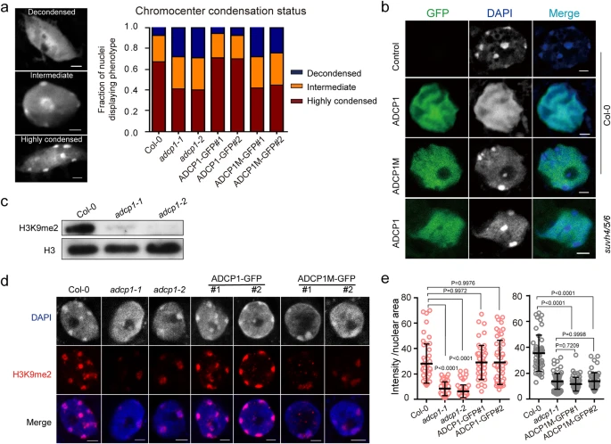

ADCP1 is required for heterochromatin formation. **a** Relative frequencies of decondensed, partially decondensed (intermediate), or wild-type chromocenters in DAPI-stained nuclei of wild-type Col-0, *adcp* mutants and ADCP1/ADCP1M complementary plants. *N* = 150. Representative nuclear condensation status stained with DAPI is showed on the left. Bar = 2 μm. **b** Transient expression of 35 S:ADCP1: GFP or 35 S:ADCP1M: GFP in protoplasts of Col-0 and *suvh456*. After 14 h of protoplasts transformation, GFP signals were observed (showed in green, and DAPI is blue). Bar = 2μm. **c** H3K9me2 western blot in Col-0 and *adcp1* mutants. **d** H3K9me2 immunostaining in Col-0, *adcp* mutants and ADCP1/ADCP1M complementary plants. Bar = 2 μm. **e** Quantification of H3K9me2 immunostaining in panel **d**, the intensity is normalized to the nuclear area. *N* = 50. The black line represents mean ± SD. The red circles and gray circles are two independent experiments. *P* values from one-way ANOVA analysis are reported. Three biological replicates were performed for all figures

[Full size image](https://www.nature.com/articles/s41422-018-0104-9/figures/4)

### ADCP1 regulates H3K9/CHG/CHH methylation levels and TE silencing

Since the morphology of heterochromatin was affected in *adcp*1 mutants, we were then prompted to check the level of H3K9me2 and DNA methylation. Firstly, we extracted total histones and performed immunoblot of H3K9me2. A significant decrease of the H3K9me2 level was observed in *adcp1* mutants compared to that in Col-0 (Fig. 4c). Quantification of H3K9me2 immunostaining was also performed. We observed a clear reduction of the H3K9me2 level in *adcp1* mutants, and this could be complemented to the level of wild type upon ADCP1 re-expression, while this couldn’t be restored upon ADCP1M re-expression (Fig. 4d, e). Consistent with these results, the native ChIP-seq data also displayed genome-wide decreased H3K9me2 level in *adcp1* mutants, especially in the pericentromeric regions that were enriched with TEs (Fig. 5a and Supplementary information, Fig. S8a, b); this result was also validated by ChIP-qPCR within the selected loci (Supplementary information, Fig. S8c). To see whether genomic DNA methylation was influenced in *adcp1* mutants, we performed the whole-genome bisulfite sequencing in the wild type and mutant plants. Over TEs, the total levels of DNA methylation at CHG/CHH sites were significantly reduced but rarely eliminated in *adcp1* mutants, while DNA methylation at CG sites remained unchanged (Fig. 5b, c, d and Supplementary information, Fig. S8d-g). Our result suggest that ADCP1 is required for the maintenance of H3K9me2 and CHG/CHH methylation levels in vivo.

**Fig. 5**

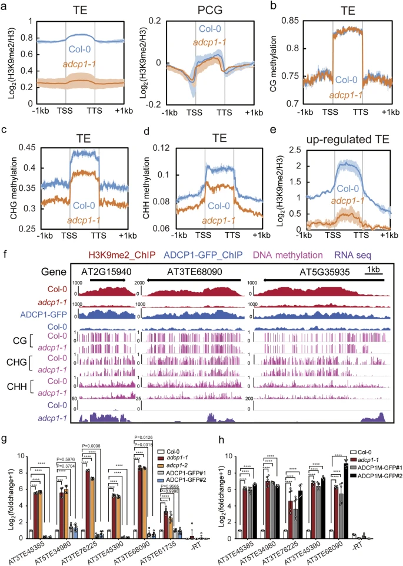

ADCP1 regulates H3K9me2 and CHG/CHH methylation levels and TE silencing. **a** Metaplots of H3K9me2 level in TEs (left) and protein coding genes (PCG, right) in Col-0 and *adcp1-1*. The shadow means the standard deviation of two biological replicates. **b**–**d** Metaplots of CG methylation (**b**), CHG (**c**) and CHH (**d**) in TEs. **e** Metaplot of H3K9me2 level in up-regulated TEs. All metaplots are plotted with mean values. The shadow means the standard deviation of two biological replicates. **f** Snapshots of all sequencing data at three selected transposon elements. ChIP-seq and RNA-seq signals are shown as RPKM, DNA methylation is shown by the ratio of methylated cytosine to all cytosine. **g**, **h** Validation of selected up-regulated TEs in Col-0, *adcp* mutants and ADCP1/ADCP1M complementary plants by RT-qPCR. PCR using primers of AT3TE6809 with templates of minus RT (-RT) was used as a negative control. The relative expression to *UBC* and *GAPDH* gene is normalized to that in Col-0. Data were shown as log<sub>2</sub> (fold change + 1). Error bars indicate standard deviations of 6 replicates, including 2 biological replicates with 3 technical replicates. The circles represent the original data. One-way ANOVA was used for the statistical analysis, *P* < 0.0001(****)

[Full size image](https://www.nature.com/articles/s41422-018-0104-9/figures/5)

Heterochromatin formation is also important for transposon silencing and genome stability maintenance. In order to explore the function of ADCP1 in gene and TE silencing, an RNA-seq experiment was performed in the wild type and mutant plants. In the *adcp1-1* mutant, 70% of the upregulated TEs were the targets of H3K9me2 and showed a largely decrease of H3K9me2 (Fig. 5e, f and Supplementary information, Fig. S8h). Besides, most of the depressed TEs belong to retrotransposons (Fig. 5f and Supplementary information, Table S6), which may have transposition activity and be dangerous to genome stability. RT-qPCR results confirmed their up-regulated expression in *adcp1* mutants, and the reactivation of TE expression in *adcp1* mutants could be repressed in the ADCP1 complementation plants (Fig. 5g), but not in plants complemented with the ADCP1M mutant (Fig. 5h). These results suggest that ADCP1 plays an important role in transcriptional silencing of TEs through modulating the level of DNA and H3K9 methylation.

### ADCP1 mediates heterochromatin phase separation

Recent studies have shown that human HP1α (upon phosphorylation) and fly HP1a have intrinsic, weak phase transition potentials,<sup>9,10</sup> and HP1α’s C-terminus negatively regulates the phase transition ability of HP1α.<sup>9</sup> Interestingly, we observed that a truncated form containing Agenet 3-6 but not full length ADCP1 has intrinsic phase transition potential (Fig. 6a), suggesting the fragment containing Agenet 1-2 also negatively regulates the phase transition ability of ADCP1. The work on animal HP1 suggests a role of phase separation in heterochromatin formation.<sup>9,10</sup> To biochemically confirm this, we prepared methyl-lysine analog (MLA)<sup>22</sup> histone H3K9me3 and reconstituted a “designer” nucleosome array (NA) with MLA H3K9me3 marks (Fig. 6b). Consistently, we showed that H3K9me3 NA promotes phase transition of HP1α and HP1a in comparison with native NA (Fig. 6b, c). Given the observation that ADCP1 and H3K9me2 co-localize to chromocenters in plant cells (Fig. 3a), similar to HP1 and H3K9me3 in animal cells,<sup>23</sup> we wondered whether ADCP1 is also involved in phase separation of H3K9me3 NA. Indeed, ADCP1 forms DNA-rich puncta with H3K9me3 NA but not with native NA in vitro (upper-middle panels, Fig. 6d). Puncta formation is H3K9me recognition-dependent as a reader pocket mutant ADCP1 failed to form puncta with H3K9me3 NA (lower panels, Fig. 6d). Several lines of evidence suggest that the puncta formation by ADCP1/H3K9me3 NA is due to phase transition: (1) the morphology of puncta is nearly a perfect round/sphere (Fig. 6d); (2) puncta formation shows sharp concentration dependence on both components (Fig. 6e); (3) ADCP1 was dynamically exchanged between puncta and ambient solution as its fluorescence recovers after being bleached (Fig. 6f).

**Fig. 6**

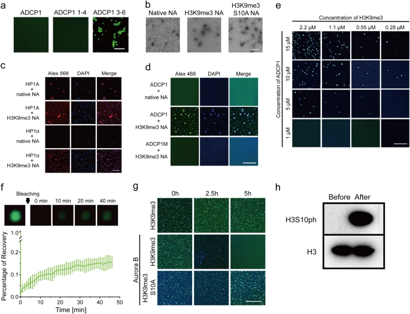

ADCP1 drives multivalent H3K9me3 nucleosome array phase separation. **a** The phase separation of ADCP1 full length, Agenet domain 1-4 and Agenet domain 3-6 protein only, bar = 20 μm. **b** Electron microscope image of native, H3K9me3 and H3K9me3S10A NA, bar = 100 nM. **c** Droplets formation of HP1A, HP1αwith H3K9me3 NA. HP1A, HP1α were labelled with Alex 568, while the NA was strained by DAPI. Bar = 20 μm. **d** Phase separation of ADCP1 with H3K9me3 NA. ADCP1 was labelled by Alex 488, while the NA was strained by DAPI. Bar = 20 μm. **e** The concentration dependence of phase separation. Bar = 20 μm. The merged images with Alex 488 fluorescence and DAPI staining were shown. **f** The FRAP of the droplets. Five droplets were bleached with 488 laser and the percentage of recovery was recorded. One of the five droplets was imaged to show the dynamic. **g** The phase separation of Aurora B treated H3K9me3 NA and H3K9me3S10A NA with ADCP1. Bar = 20 μm. **h** Western blots of H3K9me3 NA before and after aurora B treatment

[Full size image](https://www.nature.com/articles/s41422-018-0104-9/figures/6)

Similar to a phosphorylation-dependent binary switch mechanism that has been observed for HP1,<sup>6,7</sup> ITC titration showed that adjacent H3S10ph can also switch off binding between ADCP1 and H3K9me2/3 (Fig. 1d). Next we tested the responsiveness of phase-separated ADCP1-H3K9me3 NA to H3S10 phosphorylation. Both the H3K9me3 NA and the H3(S10A)K9me3 NA that harbors H3S10 alanine mutation form phase transition with ADCP1. However, phase transition of the former but not the latter can be dissolved by Aurora B treatment that causes S10 phosphorylation (Fig. 6g, h).

Collectively, the above results show that ADCP1 functions as an HP1 equivalent protein in plant to regulate heterochromatin formation through a conserved phase separation mechanism.

## DISCUSSION

HP1 in animals is crucial for heterochromatin formation and functions. However, LHP1, the homolog of HP1 in plants, functionally recognizes H3K27me3 and better resembles Polycomb proteins.<sup>11,12</sup> In contrast, the ubiquitously expressed ADCP1 binds to H3K9me2 both in vitro and in vivo and is sensitive to H3S10ph. Structurally, ADCP1 induces a “helix-loop” structure of the H3(1-10) peptide and recognizes the “R2-K4-K9me2” motif instead of the “ARKS” motif shared by H3K9 and H3K27, rendering it a specific H3K9me2 reader. For animal HP1-H3K9me2/3 interactions, the histone tail inserts as an induced β-strand to complete a β-sandwich architecture of the chromodomain, and the H3 “Q5-T6-A7-R-8-K9me2/3-S10” motif mediates most interactions.<sup>24,25</sup> Despite distinct motif recognition mechanisms, both HP1 chromodomain and ADCP1 tandem Agenet adopt a similar aromatic cage for H3K9 methylation readout.

The normal expression of ADCP1 is crucial for the heterochromatin maintenance, suggesting its role in organizing heterochromatin. The knock-out of *adcp1* leads to global decrease of methylation levels of histone H3K9 and DNA CHG/CHH sites, indicating that ADCP1 is involved in the positive feedback loop of establishing H3K9me2 and DNA methylations.<sup>15</sup> Knock-out of *adcp1* also leads to the activation of a repertoire of transposable elements, stressing its role in TE silencing and genome stability maintenance. Importantly, we further showed that phenotypic defects caused by *adcp1* knock-out could be rescued by re-introducing the wild type *adcp1* but not its reader deficient mutant. Collectively, these results suggest that ADCP1 is a key H3K9me2 reader that regulates DNA methylation and heterochromatin formation in plants.

Agenet domain is one of the “Royal family” members and abundant in plants (Supplementary Fig. S1), but its histone reader activity has not been well characterized. *Arabidopsis* ADCP1 contains three tandem Agenet domains and all these three tandem Agenet domains recognize H3K9me2. One protein contains more than one histone reader modules can empower its multivalent engagement of histone modification patterns.<sup>26</sup> For example, the presence of “PHD-Bromo” cassette in BPTF leads to the combinatorial readout of “H3K4me3-H4Kac” modification patterns at the nucleosomal level.<sup>27</sup> ADCP1 is a unique histone reader that recognizes one type of histone modification trivalently. In addition, we showed that Agenet 3-6 of ADCP1 has intrinsic phase separation ability that is inhibited and thus regulated by the presence of the Agenet 1-2. Such a feature is reminiscent of human HP1α, in which a very C-terminal region of HP1α negatively regulates the intrinsic phase transition potential of an N-terminally phosphorylated HP1α.<sup>9</sup> The multivalent and intrinsic phase transition features of ADCP1 likely render it a good scaffold protein in organizing biomolecular phase separation.<sup>28</sup> Conceivably, through the formation of dynamic nuclear condensates,<sup>29</sup> the phase-separated ADCP1 may promote the recruitment of additional client chromatin regulators such as SUVH4 or CMT3 to maintain H3K9 and DNA methylation levels. HP1 was reported to promote heterochromatin formation through H3K9me3 recognition, which could be reversed by adjacent H3S10ph.<sup>6,7</sup> Using reconstituted designer nucleosome array as a probe, we showed that plant ADCP1 could drive phase separation in vitro in an H3K9me3-dependent manner. Remarkably, such phase transition could be switched off by additional H3S10 phosphorylation catalyzed by Aurora B, suggesting a “phospho-switch” mechanism for down-regulation of the ACDP1-mediated phase separation.

In sum, ADCP1 shows highly common features with HP1 in its histone binding activity, epigenetic silencing function and phase transition capability despite their distinct domain compositions. Based on these properties of ADCP1, we hold the view that ADCP1 rather than LHP1 constitutes the HP1 equivalent in plants to regulate heterochromatin formation. The mechanistically convergent evolution of two distally related proteins for a consensus function calls attention to the complexity and conservation of epigenetic regulation among different kingdoms of life. Considering the wide distribution of ADCP1 orthologues in plants, we envision that our studies shall pave the way for many new initiatives centering on the role of the Agenet domain family members in epigenetic regulation and beyond.

## MATERIALS AND METHODS

### Plasmids and plant strains

The cDNAs encoding the Agenet 1/2 domain (amino acids 31-177), Agenet 3/4 domain (amino acids 201-355), Agenet 5/6 domain (amino acids 376-517), Agenet 1-4 domain (amino acids 1-355) and Agenet 3-6 (amino acids 201-517) of ADCP1 were cloned into the pGEX6p vectors (GE Healthcare). Full length ADCP1 was cloned into the pRSFDuet vectors with a C-terminal His-tag. Point mutations were generated using the QuikChange site-directed mutagenesis kit (Stratagene). Histone peptides bearing different modifications were synthesized at SciLight Biotechnology.

Seeds of wild-type *Arabidopsis* ecotype Col-0 (Columbia-0) and T-DNA insertion mutant *adcp1-1* (SALK_130936) were obtained from the Nottingham *Arabidopsis* Stock Centre, UK. Genotyping primers are listed in Supplementary information, Table S3. The plant CRISPR/Cas9 system<sup>30</sup> was used to generate the genomic deletion of ADCP1 gene (*adcp1-2*). The sequences of two sgRNAs are listed in Supplementary information, Table S3, and the locations of these sgRNAs are indicated in Supplementary information, Fig. S7a. Sequencing analysis of 2 individual mutations of *adcp1-2* are shown in Supplementary information, Fig. S7b. *suvh456* was previously described.<sup>31,32</sup> The overexpression plasmids were constructed by cloning the CDS of ADCP1 into PUC19 vectors containing 35S promoter and eGFP tag. For complementation experiments, *ADCP1* genomic DNA from 2 kb upstream of ATG to 1 kb downstream of TAG were cloned into pBar1001 (modified based on pCAMBIA1300 construct with replacement of plant resistance marker Hygromycin to Basta) and the GUS/GFP tags were fused to the N-terminal of ADCP1. These vectors were constructed by Fast-Cloning method<sup>33</sup> and the primers are listed in Supplementary information, Table S3.

### Protein expression and purification

The tandem Agenet domains of ADCP1 (Agenet 1/2, Agenet 3/4, Agenet 5/6, Agenet 1-4 and Agenet 3-6) were cloned into pGEX6p vector and expressed with an N-terminal GST-tag in *Escherichia coli* strain BL21 (DE3) in the presence of 0.4 mM IPTG. Overnight-induced cells were collected by centrifugation and re-suspended in lysis buffer: 100 mM NaCl, 20 mM Tris-HCl, pH 7.5. Then cells were lysed with an Emulsiflex C3 (Avestin) high-pressure homogenizer. After centrifugation at 16,770 × g, the supernatant was applied to a GST column, and proteins were directly digested on the column overnight by the PreScission proteases. The resultant protein was further purified by anion-exchange chromatography using a HiTrap Q column (GE Healthcare). The peaks eluted were applied to a Superdex 75 10/300GL (GE Healthcare) gel filtration column. The Se-methionine-substituted Agenet 3/4 protein was expressed in M9 medium supplemented with amino acids Lys, Thr, Phe, Leu, Ile, Val and Se-Met, and purified using the same protocol as the wild-type protein.

Full-length MBP-ADCP1-His was loaded on HisTrap column (GE Healthcare). The protein was eluted with the buffer 100 mM NaCl, 20 mM Tris-HCl, pH 7.5, 500 mM imidazole and the N-terminal MBP tag was removed with TEV protease. Full-length ADCP1-His was loaded on HisTrap column and the eluted peak was applied to Q column. The eluted protein was applied to a Superdex 200 10/300GL (GE Healthcare) gel filtration column.

All proteins were stored in 100 mM NaCl, 20 mM Tris-HCl, pH 7.5, at ~ 10 mg/ml in a −80 °C freezer. Mutants were expressed and purified using essentially the same procedure as for the wild-type proteins.

### Protein crystallography

Crystallization was performed by the sitting-drop vapor diffusion method under 18 °C by mixing equal volumes (1–2 μL) of protein and reservoir solution. Free Agenet 3/4 (8-10 mg/mL) crystals were grown in the solution containing 2.1 M DL-Malic acid pH 7.0. Crystals were directly flash frozen in liquid nitrogen for data collection at 100 K. For complex crystallization, Agenet 1/2 (8–10 mg/ml) and Agenet 3/4 (8–10 mg/ml) were first incubated with histone peptides (SciLight Biotechnology) at molar ratio of 1:5 for about 1 h. Crystals of Agenet1/2-H3K9me1 and Agenet1/2-H3K9me2 could be obtained under 28% (w/v) PEG 4000, 0.1 M sodium acetate, pH 5.0, 0.2 M ammonium acetate. Crystals were briefly soaked in a cryo-protectant composed of reservoir solution supplemented with 8% glycerol, and were flash frozen in liquid nitrogen for data collection at 100 K. Crystals of Agenet 3/4-H3K9me2 could be obtained under 2.0 M ammonium formate, 0.1 M HepesNa, pH 7.5. Crystals were directly flash frozen in liquid nitrogen for data collection at 100 K. All data sets were collected at beamline BL17U at the Shanghai Synchrotron Radiation Facility at 0.9793 Å. All data were indexed, integrated and merged using the HKL2000 software package.<sup>34</sup>

The phase of free Agenet was solved by the single-wavelength anomalous dispersion method using PHENIX software. The structures of Agenet 1/2-H3K9me1, Agenet 1/2-H3K9me2 and Agenet 3/4-H3K9me2 complexes were solved by molecular replacement using MOLREP<sup>35</sup> with the free Agenet 3/4 structure as a search model. All structures were refined using PHENIX,<sup>36</sup> with iterative manual model building using COOT.<sup>37</sup> Detailed structural refinement statistics are shown in Supplementary information, Table S1. All structural figures were created using PYMOL (http://www.pymol.org/).

### Surface plasmon resonance imaging

To measure the interaction between immobilized peptides and flowing proteins, an SPR imaging instrument (Kx5, Plexera, USA) was used to monitor the whole procedure in real-time. Briefly, a 3D-carbene chip with well-prepared biomolecular microarray was assembled with a plastic flow cell for sample loading. The protein samples were prepared at determined concentrations in TBS running buffer (100 mM NaCl, 20 mM Tris-HCl, pH 7.5) while a 10 mM glycine-HCl buffer (pH 2.0) was used for regeneration. A typical binding curve was obtained by flowing protein sample at 2 μL/s for 300 s’ association and then flowing running buffer for 300 s’ dissociation, followed by 200 s regeneration buffer at 3 μL/s. All the binding signals were converted to standard refractive units (RU) by calibrating every spots with 1% glycerol (w/v) in running buffer with known refractive index change (1200 RU). Binding data were collected and analyzed by a commercial SPRi analysis software (Plexera SPR Data Analysis Model, Plexera, USA).

### Isothermal titration calorimetry

For ITC measurement, synthetic histone peptides (SciLight Biotechnology) and the wild-type and mutant ADCP1 tandem Agenet domains were extensively dialyzed against ITC buffer: 100 mM NaCl, 20 mM Tris-HCl, pH 7.5. The titration was performed using a MicroCal PEAQ-ITC system (Malvern Instruments) at 25 °C. Each ITC titration consisted of 17 successive injections with 0.4 μL for the first and 2.4 μL for the rest. Usually, H3 peptides at 1 mM were titrated into ADCP1 tandem Agenet domains at 0.05–0.1 mM. The resultant ITC curves were processed using Origin 7.0 software (OriginLab) according to the ‘One Set of Sites’ fitting model.

### Immunostaining and nuclear DNA staining

Immunostaining was modified based on previously described methods.<sup>38</sup> Briefly, 1 g leaves were fixed by 4% paraformaldehyde for 20 min with vacuum and chopped in a petri dish containing 3 mL NEB1 (10 mM Tris-HCl pH 9.5, 10 mM KCl, 500 mM sucrose, 0.1% mercaptoethanol, 0.1% Triton-X 100) with scissors to get homogenate on ice. Then the homogenate was filtered with 40 μm cell strainer and centrifuged 3 min at 2500 rpm at 4℃. The pellet was re-suspended gently in 300 μL NEB2 (10 mM Tris-HCl, pH9.5, 10 mM KCl, 125 mM sucrose, 0.1% mercaptoethanol, 0.1% Triton-X 100) and loaded on the top of 600 μL NEB3 (10 mM Tris-HCl, pH 9.5, 10 mM KCl, 850 mM sucrose, 0.1% mercaptoethanol, 0.1% Triton-X 100). Centrifugation was performed at top speed at 4°C for 30 min to precipitate the nuclei. The nuclei were resuspended with 40 μL NEB1 and spread onto a slide.

For nuclear DNA staining, the slide was mounted with DAPI Fluoromount-G<sup>®</sup> (SouthernBiotech, 0100-20) and observed under confocal (Zeiss LSM780). 150 nuclei were counted from each genotype.

For immunostaining, the air-dried slide was mounted with 4% paraformaldehyde for 30 min at room temperature. After washing with PBST, the slide was blocked with 5% BSA for 1 h at 37 °C. Then the slide was incubated with primary antibody (1:100; anti-GFP, Abcam, ab290; anti-H3K9me2, Abcam, ab1220) overnight at room temperature. The slide was washed with PBST and incubated with second antibody (1:100; Goat Anti-Mouse IgG H&L (Alexa Fluor<sup>®</sup> 488), Abcam, ab150113; Goat Anti-Rabbit IgG H&L (Alexa Fluor<sup>®</sup> 555), ab150078) for 1 h at 37 °C. The slide was washed with PBST and mounted with DAPI Fluoromount-G<sup>®</sup> for confocal observation (Zeiss LSM780).

### Western blot of histones

Histone was extracted from 14-day-old leaves with the following protocols. Nuclei were extracted using Honda buffer (2.5% Ficoll 400, 5% Dextran T40, 0.4 M sucrose, 25 mM Tris–HCl, pH 7.4, 10 mM MgCl<sub>2</sub>, 10 mM β-mercaptoethanol, 0.5 mM PMSF, protease inhibitor cocktail) and lysed with histone extraction buffer (10 mM Tris-HCl, pH 7.5, 2 mM EDTA, 0.25 M HCl, 5 mM 2-mercaptoethanol β-ME, 0.2 mM PMSF). The nuclei lysis was centrifuged and the supernatant was precipitated with 25% TCA. The precipitated pellets were washed by acetone and dissolved by sample lysate (50 mM Tris-HCl pH7.4, 150 mM NaCl, 1% NP-40). The extracted histones in 2 × SDS sample buffer were boiled and loaded into SDS-PAGE. Samples were separated by SDS-PAGE, blotted onto PVDF membranes, blocked with 5% milk and subsequently incubated with anti-H3 antibodies (1:5000 dilution; Abcam, ab1791), anti-H3K9me2 (1:2000 dilution; Abcam, ab1220). HRP-linked goat anti-mouse antibodies and HRP-linked goat anti-rabbit antibodies (EASTBIO, BE0101, BE0102) were used as secondary antibodies. ECL prime western blotting detection reagent (GE) was used to induce chemiluminescence.

### Protoplast transformation

Protoplast transformation was performed as follows.<sup>39</sup> Briefly, protoplasts were extracted from 4-weeks-old leaves and transformed with plasmid mediated by 20% PEG-Ca. After 14 h of transient expression, protoplasts were fixed with 4% paraformaldehyde and stained with DAPI.

### RT-qPCR and RNA-seq

For RNA-seq, total RNA was extracted from 14-day-old leaves using Trizol (Ambion). Libraries for two biological replicates of each genotype were constructed and sequenced according to the manufacturer’s protocol (NEBNext<sup>®</sup> UltraTM Directional RNA Library Prep Kit for Illumina<sup>®</sup>). The rRNA was depleted from total RNA using Ribo-ZeroTM rRNA removal Kit (Illumina). Illumina libraries were generated and sequenced using a 2 × 150 paired-end (PE) configuration on the HiSeq instrument (Illumina). For RT-qPCR, extracted RNAs were treated with DNase I for 15 min, and the cDNA was synthesized by PrimeScript™ RT reagent Kit with gDNA Eraser (Takara, RR047A). Resulting cDNA was used for qPCR amplification using LightCycler 480 SYBR Green I Master (Roche, 4887352001) and primers are listed in Supplementary Table S3. The *UBC* and *GAPDH* genes were included as internal controls for normalization.

### ChIP-qPCR and ChIP-seq

For H3K9me2 ChIP, nuclei were extracted from 2.5 g two-week-old leaves and washed with Honda buffer. The extracted nuclei were re-suspended in MNase digestion buffer (50 mM Tris-HCl, pH 7.6, 5 mM CaCl<sub>2</sub>, 0.1 mM PMSF, 1 × cocktail protease inhibitor) including 5 μL RNase A (Takara, 2158), and incubated for 30 min at 37 °C. Next, Micrococcal Nuclease (NEB, M0247S) digestion was performed and stopped by adding EDTA to a final concentration of 10 mM. Next the nucleosomes were released by adding 0.005% SDS and rotation at 4 °C for 3 h. After centrifugation for 10 min at max speed, the supernatant was diluted and ready for IP. 50 μL Dynabeads Protein G magnetic beads (Invitrogen, 10004D) coupled with 5 μL antibody (anti-H3K9me2, ab1220; anti-H3, ab1791) were added to 1 mL sample and the mixture was rotated at 4 °C overnight. After washed by 50 mM NaCl Wash Buffer,100 mM NaCl Wash Buffer,150 mM NaCl Wash Buffer (50 mM Tris-HCl, pH 7.6, 10 mM EDTA, 50/100/150 mM NaCl, 0.1 mM PMSF, 1× cocktail protease inhibitor), TE Buffer, 10 min for each wash; the DNA was purified by phenol-chloroform for sequencing and qPCR.

For ADCP1 ChIP-seq, the protocol was modified based on previous published method.<sup>40</sup> Nuclei were extracted from 3 g 14-day-old leaves of ADCP1-GFP complementation plants (Col-0 as a control) and cross-linked in 1% formaldehyde. After stopped by 0.125 M glycine and washed by NRBT, the nuclei were suspended by nuclei lysis buffer (50 mM Tris-HCl, pH 8.0, 10 mM EDTA, 1% SDS, 1 × protease inhibitor). Then the nuclei were sonicated 3 times for 10 min (30 s on/off intervals) using the Bioruptor<sup>®</sup> Pico. The chromatin was centrifuged at max speed for 10 min and the supernatant was collected. The supernatant was diluted 10 times with ChIP dilution buffer (1.1% Triton X-100, 1.2 mM EDTA, 16.7 mM Tris-HCl, pH 8.0, 167 mM NaCl), and then anti-GFP antibody (Abcam, ab290) with a ratio of 1:500 was added for incubation. After rotating at 4 °C overnight, 50 μL Dynabeads Protein G magnetic beads (Invitrogen, 10004D) washed by ChIP dilution buffer was added to the sample. After rotating for 3 h, the beads were washed sequentially with Low Salt Buffer, High Salt Buffer, LiCl Buffer, TE Buffer (each buffer for a quick wash, and a 5 min wash). 100 μL 10% Chelex resin (Biorad, 1422842) was added to elute immune complexes. The mixture was incubated at 95 °C for 10 min at 1300 rpm, cooled to RT and incubated with 2 μL Protease K (10 mg/mL, Amresco 0706) for 1 h at 45 °C, and boiled for another 10 min at 95 °C and 1300 rpm. Then the elution was purified with phenol-chloroform for sequencing.

The ChIP-seq DNA was sonicated to 200 bp using The Covaris<sup>®</sup> S220 System and the library was constructed using ACCEL-NGS<sup>®</sup>1 S PLUS DNA LIBRARY KIT (Swift Biosciences, Cat. No. 18096) according to the manufacturer’s instruction.

### Whole genome bisulfite sequencing (BS-seq)

DNA was extracted from 14-day-old leaves with CTAB. After complete bisulfite conversion of 2 μg DNA with EZ DNA Methylation-Gold Kit (Zymo Research,D5005), the DNA was sonicated to 250 bp (Covaris) and subjected to library generation following Illumina’s manufacturer Instructions (Swift Biosciences, ACCEL-NGS<sup>®</sup> METHYL-SEQ DNA LIBRARY KIT, 30024).

### Data analysis

All libraries were sequenced on the Illumina HiSeq-PE150 platform with paired-end 150 bp read length. Base calling and FastQC were performed with standard Illumina software and then the clean reads were mapped to the *Arabidopsis* genome TAIR10 (http://www.arabidopsis.org/).

For RNAseq, reads were mapped with hisat2,<sup>41</sup> cufflinks and cuffdiff<sup>42</sup> were used to find different expressed genes. Different expressed elements in wild type and mutants were defined by applying log<sub>2</sub> (mutant /wild-type) >1 and *p* < 0.05 cutoffs. The DEGs are listed in Supplementary information, Table S7.

ChIP-seq reads were mapped with Bowtie2, allowing up to one mismatch. Only uniquely mapped reads were retained. ChIP binding peaks were called by MACS2.<sup>43</sup> DNA reads from ADCP1-GFP ChIP with transgenic plants were normalized with the ones from control ChIP with Col-0 control. ChIP reads for histone modifications were normalized with the ones of H3 ChIP, and only peaks with FDR < 0.05 were identified as enriched regions. Searches for enriched DNA motifs were performed using MEME-ChIP<sup>44</sup> and Homer<sup>45</sup> with default parameters (Supplementary information, Fig. S6f and Table S4).

BS-seq reads were mapped by Bismark<sup>46</sup> with default parameters. After removal of the PCR duplicates, the methylation information was obtained using Bismark with a cutoff of at least 4 coverage depth.

The alignments were converted to bigwig files using deepTools<sup>47</sup> and imported into the Integrative Genomics Viewer (IGV)<sup>48</sup> for visualization.

### Statistical analysis

Data were processed using Prism v.6 (GraphPad Software). Comparisons between multiple groups were analyzed by one-way ANOVA test. For qPCR, asterisks indicate significant differences compared to Col-0. *****P* < 0.0001. The uncertainty in the mean is reported as the standard deviation of the mean (SD).

### Preparation of histone proteins and DNA template

Recombinant human wild-type histone H2A, H2B, H4 proteins, and mutant H3 (H3C110A, H3K9C/C110A, H3K9C/S10A/C110A) proteins were over-expressed in *E. coli* and purified essentially as described previously.<sup>49</sup>

Plasmid of DNA template harboring 12 × 177 bp tandem repeats of Widom 601 sequence was a gift from Dr. Guohong Li in Institute of Biophysics, Chinese Academy of Sciences. Preparation of 12 × 177 bp 601 DNA template followed the method described previously.<sup>50</sup> Sequence for the 177 bp DNA repeats was listed as below with 601 DNA sequence underlined:

GAGCATCCGGATCCCCTGGAGAATCCCGGTGCCGAGGCCGCTCAATTGGTCGTAGACAGCTCTAGCACCGCTTAAACGCACGTACGCGCTGTCCCCCGCGTTTTAACCGCCAAGGGGATTACTCCCTAGTCTCCAGGCACGTGTCACATATATACATCCTGTTCCAGTGCCGGACCC

### Methyl-lysine analog (MLA) histone H3K9me3 preparation

Due to lack of sufficient H3K9me3 histone samples, we adopted the methyl-lysine analog (MLA) strategy to obtain structurally and biochemically similar analog of H3K9me3, in which a tri-methyl-aminoethyl group was introduced to the thiol group of cysteine 9 in the context of H3K9C/C110A and H3K9C/S10A/C110A histone H3 samples.<sup>22</sup> In brief, 10 mg lyophilized H3K9C/C110A or H3K9C/S10A/C110A H3 sample powder was solubilized in 980 μL solubilization buffer (1 M HepesNa, pH 7.4, 4 M guanidine hydrochloride, 10 mM D/L-methionine, 20 mM DTT) by incubation at 37 °C for 1 h. 100 mg bromocholine bromide (TCI) was then added to the solution to initiate the chemical reaction. After incubation at 50 °C for 2.5 h, 10 μL of 1 M DTT was added and the mixture was incubated for another 2.5 hs. By the end of the reaction, 50 μL 2-mercaptoethanol was added to quench extra unconsumed bromocholine bromide. Before octamer reconstitution, the MLA H3 proteins were exchanged to unfolding buffer (20 mM HepesNa, pH 7.4, 6 M guanidine hydrochloride, 10 mM DTT) using PD-10 desalting columns (GE Healthcare), and the tri-methylated lysine 9 analogs on H3K9C/C110A and H3K9C/S10A/S110A proteins were confirmed by western blot assays using monoclonal anti-Histone H3K9me3 antibody (Abcam).

### Reconstitution of 12× nucleosome chromatin

The respective histone octamers were reconstituted using the method of serial dialysis. Briefly, equal molar amounts of individual histones in unfolding buffer (20 mM HepesNa, pH 7.4, 6 M guanidine hydrochloride) were combined and dialyzed against refolding buffer (20 mM HepesNa, pH 7.4, 2 M NaCl). Octamers were further purified through a Superdex 200 10/300 GL column (GE Healthcare).

Reconstitution of 12× nucleosome chromatin was performed at 4 °C using the salt dialysis method as previously reported with minor modifications.<sup>49</sup> DNA template harboring 12 × 177 bp tandem repeats of Widom 601 sequence and respective histone octamers were mixed together with the molar ratio of 1:12, and dialyzed over 18 h in HNE buffer (40 mM HepesNa, pH 7.4, 2 M NaCl, 0.5 mM EDTA, 1 mM DTT, 0.5 mM Benzamidine). The mixture was continuously diluted by slowly adding LNE buffer (40 mM HepesNa, pH 7.4, 350 mM NaCl, 0.5 mM EDTA, 1 mM DTT, 0.5 mM Benzamidine) to decrease the NaCl concentration from 2 M to 0.6 M. The reconstituted 12× nucleosome chromatin was further dialyzed against FNE buffer (20 mM HepesNa, pH 7.4, 50 mM NaCl) for 3 h before use.

### Negative stain and electron microscopy

Before grid preparation, all samples were co-dialyzed against the same buffer (20 mM HepesNa, pH 7.4, 50 mM NaCl) overnight, and then, 0.04 μM respective 12 × nucleosome chromatins were used for negative stain.

For negative staining, the copper grids supported by a thin layer of lacey carbon film (Beijing Zhongjingkeyi Technology, China) were glow-discharged. 4 mL of each sample at a concentration of ~ 0.04 μM were applied onto the grid for 1 min, and then the grid was washed in uranyl acetate (2% w/v) for 30 seconds before drying. Images were taken on an FEI Tecnai Spirit Bio TWIN microscope operating at 120 kV.

### Aurora B, HP1a, and HP1α purification

Human Aurora B kinase cDNA was cloned into a pET Duet (Novagen) with a His-MBP tag in N-terminus. HP1a and HP1α were cloned into a pRSFDuet vector (Novagen) with a 6 × His tag at the N-terminus. All proteins were expressed in *E. coli* BL21 (DE3). Cells were cultured to OD600 0.6 at 37 °C and induced at 18 °C with 0.5 mM IPTG overnight. Cells were ultrasonically broken down in the buffer (20 mM HepesNa 500 mM NaCl, pH 8.0), and then centrifuged at 20000 × g for 40 min. The supernatant was incubated with Ni resin followed by washing resin with washing buffer (40 mM imidazole, 20 mM HepesNa, pH 8.0, 500 mM NaCl). The proteins were eluted with elution buffer (400 mM imidazole, 20 mM HepesNa, pH 8.0, 500 mM NaCl). The proteins were further purified with ion exchange chromatography and size-exclusion chromatography.

### Data access

The sequencing data have been deposited into Gene Expression Omnibus (GEO) with the accession number GSE118063. The atomic coordinates and structure factors have been deposited into Protein Data Bank under accession codes 6IE4 for ADCP1-Agenet1/2-H3(1-15)K9me1, 6IE5 for ADCP1-Agenet3/4, 6IE6 for ADCP1-Agenet3/4-H3(1-15)K9me2, and 6IE7 for ADCP1-Agenet1/2-H3(1-15)K9me2.

## References

1. Grewal, S. I. & Jia, S. Heterochromatin revisited. *Nat. Rev. Genet* **8**, 35–46 (2007).

   [Article](https://doi.org/10.1038%2Fnrg2008) [CAS](https://www.nature.com/articles/cas-redirect/1:CAS:528:DC%2BD28Xhtlakt7fO) [Google Scholar](http://scholar.google.com/scholar_lookup?&title=Heterochromatin%20revisited&journal=Nat.%20Rev.%20Genet&doi=10.1038%2Fnrg2008&volume=8&pages=35-46&publication_year=2007&author=Grewal%2CSI&author=Jia%2CS)
2. Allshire, R. C. & Madhani, H. D. Ten principles of heterochromatin formation and function. *Nat. Rev. Mol. Cell Biol.* **19**, 229–244 (2018).

   [Article](https://doi.org/10.1038%2Fnrm.2017.119) [CAS](https://www.nature.com/articles/cas-redirect/1:CAS:528:DC%2BC2sXhvFKhu7nL) Google Scholar
3. Maison, C. & Almouzni, G. HP1 and the dynamics of heterochromatin maintenance. *Nat. Rev. Mol. Cell Biol.* **5**, 296–304 (2004).

   [Article](https://doi.org/10.1038%2Fnrm1355) [CAS](https://www.nature.com/articles/cas-redirect/1:CAS:528:DC%2BD2cXivV2itr8%3D) Google Scholar
4. Lachner, M., O’Carroll, D., Rea, S., Mechtler, K. & Jenuwein, T. Methylation of histone H3 lysine 9 creates a binding site for HP1 proteins. *Nature* **410**, 116–120 (2001).

   [Article](https://doi.org/10.1038%2F35065132) [CAS](https://www.nature.com/articles/cas-redirect/1:CAS:528:DC%2BD3MXhvVSltr8%3D) Google Scholar
5. Bannister, A. J. et al. Selective recognition of methylated lysine 9 on histone H3 by the HP1 chromo domain. *Nature* **410**, 120–124 (2001).

   [Article](https://doi.org/10.1038%2F35065138) [CAS](https://www.nature.com/articles/cas-redirect/1:CAS:528:DC%2BD3MXhvVSltrY%3D) Google Scholar
6. Fischle, W. et al. Regulation of HP1-chromatin binding by histone H3 methylation and phosphorylation. *Nature* **438**, 1116–1122 (2005).

   [Article](https://doi.org/10.1038%2Fnature04219) [CAS](https://www.nature.com/articles/cas-redirect/1:CAS:528:DC%2BD2MXhtlakurzL) Google Scholar
7. Hirota, T., Lipp, J. J., Toh, B. H. & Peters, J. M. Histone H3 serine 10 phosphorylation by Aurora B causes HP1 dissociation from heterochromatin. *Nature* **438**, 1176–1180 (2005).

   [Article](https://doi.org/10.1038%2Fnature04254) [CAS](https://www.nature.com/articles/cas-redirect/1:CAS:528:DC%2BD2MXhtlakurzF) Google Scholar
8. Lomberk, G., Wallrath, L. & Urrutia, R. The Heterochromatin Protein 1 family. *Genome Biol.* **7**, 228 (2006).

   [Article](https://link.springer.com/doi/10.1186/gb-2006-7-7-228) Google Scholar
9. Larson, A. G. et al. Liquid droplet formation by HP1alpha suggests a role for phase separation in heterochromatin. *Nature* **547**, 236–240 (2017).

   [Article](https://doi.org/10.1038%2Fnature22822) [CAS](https://www.nature.com/articles/cas-redirect/1:CAS:528:DC%2BC2sXhtVequrbI) Google Scholar
10. Strom, A. R. et al. Phase separation drives heterochromatin domain formation. *Nature* **547**, 241–245 (2017).

    [Article](https://doi.org/10.1038%2Fnature22989) [CAS](https://www.nature.com/articles/cas-redirect/1:CAS:528:DC%2BC2sXhtVequrfN) Google Scholar
11. Turck, F. et al. Arabidopsis TFL2/LHP1 specifically associates with genes marked by trimethylation of histone H3 lysine 27. *PLoS Genet* **3**, e86 (2007).

    [Article](https://doi.org/10.1371%2Fjournal.pgen.0030086) Google Scholar
12. Zhang, X. et al. The Arabidopsis LHP1 protein colocalizes with histone H3 Lys27 trimethylation. *Nat. Struct. Mol. Biol.* **14**, 869–871 (2007).

    [Article](https://doi.org/10.1038%2Fnsmb1283) [CAS](https://www.nature.com/articles/cas-redirect/1:CAS:528:DC%2BD2sXpvFKlu7c%3D) Google Scholar
13. Maurer-Stroh, S. et al. The Tudor domain ‘Royal Family’: Tudor, plant Agenet, Chromo, PWWP and MBT domains. *Trends Biochem Sci.* **28**, 69–74 (2003).

    [Article](https://doi.org/10.1016%2FS0968-0004%2803%2900004-5) [CAS](https://www.nature.com/articles/cas-redirect/1:CAS:528:DC%2BD3sXptlyhtQ%3D%3D) Google Scholar
14. Jackson, J. P. et al. Dimethylation of histone H3 lysine 9 is a critical mark for DNA methylation and gene silencing in Arabidopsis thaliana. *Chromosoma* **112**, 308–315 (2004).

    [Article](https://link.springer.com/doi/10.1007/s00412-004-0275-7) [CAS](https://www.nature.com/articles/cas-redirect/1:CAS:528:DC%2BD2cXisV2isbs%3D) Google Scholar
15. Du, J., Johnson, L. M., Jacobsen, S. E. & Patel, D. J. DNA methylation pathways and their crosstalk with histone methylation. *Nat. Rev. Mol. Cell Biol.* **16**, 519–532 (2015).

    [Article](https://doi.org/10.1038%2Fnrm4043) [CAS](https://www.nature.com/articles/cas-redirect/1:CAS:528:DC%2BC2MXhtlOrtrvO) Google Scholar
16. Underwood, C. J., Henderson, I. R. & Martienssen, R. A. Genetic and epigenetic variation of transposable elements in Arabidopsis. *Curr. Opin. Plant Biol.* **36**, 135–141 (2017).

    [Article](https://doi.org/10.1016%2Fj.pbi.2017.03.002) [CAS](https://www.nature.com/articles/cas-redirect/1:CAS:528:DC%2BC2sXksV2htb4%3D) Google Scholar
17. Zhao, S. et al. Kinetic and high-throughput profiling of epigenetic interactions by 3D-carbene chip-based surface plasmon resonance imaging technology. *P Natl. Acad. Sci. USA* **114**, E7245–E7254 (2017).

    [Article](https://doi.org/10.1073%2Fpnas.1704155114) [CAS](https://www.nature.com/articles/cas-redirect/1:CAS:528:DC%2BC2sXhtlWms7%2FL) Google Scholar
18. Zhao, S., Zhang, B. C., Yang, M., Zhu, J. S. & Li, H. T. Systematic Profiling of Histone Readers in Arabidopsis thaliana. *Cell Rep.* **22**, 1090–1102 (2018).

    [Article](https://doi.org/10.1016%2Fj.celrep.2017.12.099) [CAS](https://www.nature.com/articles/cas-redirect/1:CAS:528:DC%2BC1cXhvFagsbk%3D) Google Scholar
19. Machida, S. et al. Structural Basis of Heterochromatin Formation by Human HP1. *Mol. Cell* **69**, 385 (2018).

    [Article](https://doi.org/10.1016%2Fj.molcel.2017.12.011) [CAS](https://www.nature.com/articles/cas-redirect/1:CAS:528:DC%2BC1cXovVSgsQ%3D%3D) Google Scholar
20. Gel, B. et al. regioneR: an R/Bioconductor package for the association analysis of genomic regions based on permutation tests. *Bioinformatics* **32**, 289–291 (2016).

    [CAS](https://www.nature.com/articles/cas-redirect/1:CAS:528:DC%2BC28XhsVWhurnL) [PubMed](http://www.ncbi.nlm.nih.gov/entrez/query.fcgi?cmd=Retrieve&db=PubMed&dopt=Abstract&list_uids=26424858) Google Scholar
21. Roudier, F. et al. Integrative epigenomic mapping defines four main chromatin states in Arabidopsis. *EMBO J.* **30**, 1928–1938 (2011).

    [Article](https://doi.org/10.1038%2Femboj.2011.103) [CAS](https://www.nature.com/articles/cas-redirect/1:CAS:528:DC%2BC3MXks1agtrk%3D) Google Scholar
22. Simon, M. D. et al. The site-specific installation of methyl-lysine analogs into recombinant histones. *Cell* **128**, 1003–1012 (2007).

    [Article](https://doi.org/10.1016%2Fj.cell.2006.12.041) [CAS](https://www.nature.com/articles/cas-redirect/1:CAS:528:DC%2BD2sXjvVSnsrs%3D) Google Scholar
23. Badugu, R., Shareef, M. M. & Kellum, R. Novel Drosophila heterochromatin protein 1 (HP1)/origin recognition complex-associated protein (HOAP) repeat motif in HP1/HOAP interactions and chromocenter associations. *J. Biol. Chem.* **278**, 34491–34498 (2003).

    [Article](https://doi.org/10.1074%2Fjbc.M305262200) [CAS](https://www.nature.com/articles/cas-redirect/1:CAS:528:DC%2BD3sXmvVCqtrc%3D) Google Scholar
24. Nielsen, P. R. et al. Structure of the HP1 chromodomain bound to histone H3 methylated at lysine 9. *Nature* **416**, 103–107 (2002).

    [Article](https://doi.org/10.1038%2Fnature722) [CAS](https://www.nature.com/articles/cas-redirect/1:CAS:528:DC%2BD38Xitlaisbg%3D) Google Scholar
25. Jacobs, S. A. & Khorasanizadeh, S. Structure of HP1 chromodomain bound to a lysine 9-methylated histone H3 tail. *Science* **295**, 2080–2083 (2002).

    [Article](https://doi.org/10.1126%2Fscience.1069473) [CAS](https://www.nature.com/articles/cas-redirect/1:CAS:528:DC%2BD38Xit1Ohsb8%3D) Google Scholar
26. Ruthenburg, A. J., Li, H., Patel, D. J. & Allis, C. D. Multivalent engagement of chromatin modifications by linked binding modules. *Nat. Rev. Mol. Cell Biol.* **8**, 983–994 (2007).

    [Article](https://doi.org/10.1038%2Fnrm2298) [CAS](https://www.nature.com/articles/cas-redirect/1:CAS:528:DC%2BD2sXhtlCrsb3L) Google Scholar
27. Ruthenburg, A. J. et al. Recognition of a mononucleosomal histone modification pattern by BPTF via multivalent interactions. *Cell* **145**, 692–706 (2011).

    [Article](https://doi.org/10.1016%2Fj.cell.2011.03.053) [CAS](https://www.nature.com/articles/cas-redirect/1:CAS:528:DC%2BC3MXmvFWhtL4%3D) Google Scholar
28. Banani, S. F., Lee, H. O., Hyman, A. A. & Rosen, M. K. Biomolecular condensates: organizers of cellular biochemistry. *Nat. Rev. Mol. Cell Biol.* **18**, 285–298 (2017).

    [Article](https://doi.org/10.1038%2Fnrm.2017.7) [CAS](https://www.nature.com/articles/cas-redirect/1:CAS:528:DC%2BC2sXjt1agsrw%3D) Google Scholar
29. Plys, A. J. & Kingston, R. E. Dynamic condensates activate transcription. *Science* **361**, 329–330 (2018).

    [Article](https://doi.org/10.1126%2Fscience.aau4795) [CAS](https://www.nature.com/articles/cas-redirect/1:CAS:528:DC%2BC1cXhsVKlsbfF) Google Scholar
30. Wang, Z. P. et al. Egg cell-specific promoter-controlled CRISPR/Cas9 efficiently generates homozygous mutants for multiple target genes in Arabidopsis in a single generation. *Genome Biol.* **16**, 144 (2015).

    [Article](https://link.springer.com/doi/10.1186/s13059-015-0715-0) Google Scholar
31. Yelagandula, R. et al. The histone variant H2A.W defines heterochromatin and promotes chromatin condensation in Arabidopsis. *Cell* **158**, 98–109 (2014).

    [Article](https://doi.org/10.1016%2Fj.cell.2014.06.006) [CAS](https://www.nature.com/articles/cas-redirect/1:CAS:528:DC%2BC2cXhtFWgur%2FP) Google Scholar
32. Ebbs, M. L. & Bender, J. Locus-specific control of DNA methylation by the Arabidopsis SUVH5 histone methyltransferase. *Plant Cell* **18**, 1166–1176 (2006).

    [Article](https://doi.org/10.1105%2Ftpc.106.041400) [CAS](https://www.nature.com/articles/cas-redirect/1:CAS:528:DC%2BD28XkslCmurc%3D) Google Scholar
33. Li, C. et al. FastCloning: a highly simplified, purification-free, sequence- and ligation-independent PCR cloning method. *BMC Biotechnol.* **11**, 92 (2011).

    [Article](https://link.springer.com/doi/10.1186/1472-6750-11-92) [CAS](https://www.nature.com/articles/cas-redirect/1:CAS:528:DC%2BC3MXhsVaks7bP) Google Scholar
34. Otwinowski, Z. & Minor, W. Processing of X-ray diffraction data collected in oscillation mode. *Methods Enzymol.* **276**, 307–326 (1997).

    [Article](https://doi.org/10.1016%2FS0076-6879%2897%2976066-X) [CAS](https://www.nature.com/articles/cas-redirect/1:CAS:528:DyaK2sXivFehsbw%3D) Google Scholar
35. Vagin, A. & Teplyakov, A. Molecular replacement with MOLREP. *Acta Crystallogr D. Biol. Crystallogr* **66**, 22–25 (2010).

    [Article](https://doi.org/10.1107%2FS0907444909042589) [CAS](https://www.nature.com/articles/cas-redirect/1:CAS:528:DC%2BC3cXit1Kktw%3D%3D) Google Scholar
36. Adams, P. D. et al. PHENIX: a comprehensive Python-based system for macromolecular structure solution. *Acta Crystallogr D. Biol. Crystallogr* **66**, 213–221 (2010).

    [Article](https://doi.org/10.1107%2FS0907444909052925) [CAS](https://www.nature.com/articles/cas-redirect/1:CAS:528:DC%2BC3cXhs1Sisbc%3D) Google Scholar
37. Emsley, P. & Cowtan, K. Coot: model-building tools for molecular graphics. *Acta Crystallogr D. Biol. Crystallogr* **60**, 2126–2132 (2004).

    [Article](https://doi.org/10.1107%2FS0907444904019158) Google Scholar
38. Han, Y. F. et al. SUVR2 is involved in transcriptional gene silencing by associating with SNF2-related chromatin-remodeling proteins in Arabidopsis. *Cell Res* **24**, 1445–1465 (2014).

    [Article](https://doi.org/10.1038%2Fcr.2014.156) [CAS](https://www.nature.com/articles/cas-redirect/1:CAS:528:DC%2BC2cXhvF2msr7M) Google Scholar
39. Yoo, S. D., Cho, Y. H. & Sheen, J. Arabidopsis mesophyll protoplasts: a versatile cell system for transient gene expression analysis. *Nat. Protoc.* **2**, 1565–1572 (2007).

    [Article](https://doi.org/10.1038%2Fnprot.2007.199) [CAS](https://www.nature.com/articles/cas-redirect/1:CAS:528:DC%2BD2sXhtFahur3I) Google Scholar
40. Sun, Q., Csorba, T., Skourti-Stathaki, K., Proudfoot, N. J. & Dean, C. R-Loop stabilization represses antisense transcription at the *Arabidopsis* *FLC* locus. *Science* **340**, 619–621 (2013).

    [Article](https://doi.org/10.1126%2Fscience.1234848) [CAS](https://www.nature.com/articles/cas-redirect/1:CAS:528:DC%2BC3sXmslWksbo%3D) Google Scholar
41. Pertea, M., Kim, D., Pertea, G. M., Leek, J. T. & Salzberg, S. L. Transcript-level expression analysis of RNA-seq experiments with HISAT, StringTie and Ballgown. *Nat. Protoc.* **11**, 1650–1667 (2016).

    [Article](https://doi.org/10.1038%2Fnprot.2016.095) [CAS](https://www.nature.com/articles/cas-redirect/1:CAS:528:DC%2BC28XhsVCgsbzI) Google Scholar
42. Trapnell, C. et al. Differential gene and transcript expression analysis of RNA-seq experiments with TopHat and Cufflinks. *Nat. Protoc.* **7**, 562–578 (2012).

    [Article](https://doi.org/10.1038%2Fnprot.2012.016) [CAS](https://www.nature.com/articles/cas-redirect/1:CAS:528:DC%2BC38Xjt1Cjsrc%3D) Google Scholar
43. Zhang, Y. et al. Model-based Analysis of ChIP-Seq (MACS). *Genome Biol.* **9**, R137 (2008).

    [Article](https://link.springer.com/doi/10.1186/gb-2008-9-9-r137) [Google Scholar](http://scholar.google.com/scholar_lookup?&title=Model-based%20Analysis%20of%20ChIP-Seq%20%28MACS%29&journal=Genome%20Biol.&doi=10.1186%2Fgb-2008-9-9-r137&volume=9&publication_year=2008&author=Zhang%2CY)
44. Machanick, P. & Bailey, T. L. MEME-ChIP: motif analysis of large DNA datasets. *Bioinformatics* **27**, 1696–1697 (2011).

    [Article](https://doi.org/10.1093%2Fbioinformatics%2Fbtr189) [CAS](https://www.nature.com/articles/cas-redirect/1:CAS:528:DC%2BC3MXntFGkurw%3D) Google Scholar
45. Heinz, S. et al. Simple combinations of lineage-determining transcription factors prime cis-regulatory elements required for macrophage and B cell identities. *Mol. Cell* **38**, 576–589 (2010).

    [Article](https://doi.org/10.1016%2Fj.molcel.2010.05.004) [CAS](https://www.nature.com/articles/cas-redirect/1:CAS:528:DC%2BC3cXns1SlsLc%3D) Google Scholar
46. Krueger, F. & Andrews, S. R. Bismark: a flexible aligner and methylation caller for Bisulfite-Seq applications. *Bioinformatics* **27**, 1571–1572 (2011).

    [Article](https://doi.org/10.1093%2Fbioinformatics%2Fbtr167) [CAS](https://www.nature.com/articles/cas-redirect/1:CAS:528:DC%2BC3MXmvVWqurw%3D) Google Scholar
47. Ramirez, F. et al. deepTools2: a next generation web server for deep-sequencing data analysis. *Nucleic Acids Res* **44**, W160–W165 (2016).

    [Article](https://doi.org/10.1093%2Fnar%2Fgkw257) [CAS](https://www.nature.com/articles/cas-redirect/1:CAS:528:DC%2BC2sXhtV2itrfI) Google Scholar
48. Robinson, J. T. et al. Integrative genomics viewer. *Nat. Biotechnol.* **29**, 24 (2011).

    [Article](https://doi.org/10.1038%2Fnbt.1754) [CAS](https://www.nature.com/articles/cas-redirect/1:CAS:528:DC%2BC3MXjsFWrtg%3D%3D) [Google Scholar](http://scholar.google.com/scholar_lookup?&title=Integrative%20genomics%20viewer&journal=Nat.%20Biotechnol.&doi=10.1038%2Fnbt.1754&volume=29&publication_year=2011&author=Robinson%2CJT)
49. Dyer, P. N. et al. Reconstitution of nucleosome core particles from recombinant histones and DNA. *Methods Enzymol.* **375**, 23–44 (2004).

    [Article](https://doi.org/10.1016%2FS0076-6879%2803%2975002-2) [CAS](https://www.nature.com/articles/cas-redirect/1:CAS:528:DC%2BD2cXhvFSiurg%3D) Google Scholar
50. Luger, K., Rechsteiner, T. J. & Richmond, T. J. Preparation of nucleosome core particle from recombinant histones. *Methods Enzymol.* **304**, 3–19 (1999).

    [Article](https://doi.org/10.1016%2FS0076-6879%2899%2904003-3) [CAS](https://www.nature.com/articles/cas-redirect/1:CAS:528:DC%2BD3cXmsVOjtrg%3D) Google Scholar

[Download references](https://citation-needed.springer.com/v2/references/10.1038/s41422-018-0104-9?format=refman&flavour=references)

## Acknowledgements

We thank the staff members at beamline BL17U of the Shanghai Synchrotron Radiation Facility and Dr. S. Fan at Tsinghua Center for Structural Biology for their assistance in data collection and the China National Center for Protein Sciences Beijing for providing facility support. This work was supported by grants from the National Key R&D Program (2016YFA0500700 to H.L., and 2016YFA0500800 to Q.S.), the National Science Foundation of China (31725014, 91753203 to H.L., and 31571322 to Q.S.), and the Tsinghua University Initiative Scientific Research Program (to H.L. and Q.S.). Q.S. and P.L. are supported by the 1000 Young Talent Program of China.

## Author information

Author notes

1. These authors contributed equally: Shuai Zhao, Lingling Cheng, Yifei Gao, Baichao Zhang

### Authors and Affiliations

1. MOE Key Laboratory of Protein Sciences, Beijing Advanced Innovation Center for Structural Biology, Tsinghua-Peking Joint Center for Life Sciences, School of Life Sciences, Tsinghua University, Beijing, 100084, China

   Shuai Zhao, Lingling Cheng, Yifei Gao, Baichao Zhang, Xiangdong Zheng, Liang Wang, Pilong Li, Qianwen Sun & Haitao Li
2. Department of Basic Medical Sciences, School of Medicine, Tsinghua University, Beijing, 100084, China

   Shuai Zhao, Baichao Zhang, Xiangdong Zheng & Haitao Li

### Contributions

H.L., Q.S., P. L. conceived the study and designed the major experiments. S.Z., B.Z., H.L. discovered ACDP1 and performed structural and biochemical studies; L.C., and Q.S. performed plant biology studies; Y.G. X.Z, L.W. and P.L. performed phase separation studies. H.L., Q.S., P.L., Z.S., L.C., and Y.G. analyzed the data and wrote the manuscript.

### Corresponding authors

Correspondence to Pilong Li, Qianwen Sun or Haitao Li.

## Ethics declarations

### Competing interests

The authors declare no competing interests.

## Electronic supplementary material

### [Supplementary information, Figure S1](https://static-content.springer.com/esm/art%3A10.1038%2Fs41422-018-0104-9/MediaObjects/41422_2018_104_MOESM1_ESM.pdf)

### [Supplementary information, Figure S2](https://static-content.springer.com/esm/art%3A10.1038%2Fs41422-018-0104-9/MediaObjects/41422_2018_104_MOESM2_ESM.pdf)

### [Supplementary information, Figure S3](https://static-content.springer.com/esm/art%3A10.1038%2Fs41422-018-0104-9/MediaObjects/41422_2018_104_MOESM3_ESM.pdf)

### [Supplementary information, Figure S4](https://static-content.springer.com/esm/art%3A10.1038%2Fs41422-018-0104-9/MediaObjects/41422_2018_104_MOESM4_ESM.pdf)

### [Supplementary information, Figure S5](https://static-content.springer.com/esm/art%3A10.1038%2Fs41422-018-0104-9/MediaObjects/41422_2018_104_MOESM5_ESM.pdf)

### [Supplementary information, Figure S6](https://static-content.springer.com/esm/art%3A10.1038%2Fs41422-018-0104-9/MediaObjects/41422_2018_104_MOESM6_ESM.pdf)

### [Supplementary information, Figure S7](https://static-content.springer.com/esm/art%3A10.1038%2Fs41422-018-0104-9/MediaObjects/41422_2018_104_MOESM7_ESM.pdf)

### [Supplementary information, Table S1](https://static-content.springer.com/esm/art%3A10.1038%2Fs41422-018-0104-9/MediaObjects/41422_2018_104_MOESM8_ESM.pdf)

### [Supplementary information, Table S2](https://static-content.springer.com/esm/art%3A10.1038%2Fs41422-018-0104-9/MediaObjects/41422_2018_104_MOESM9_ESM.pdf)

### [Supplementary information, Table S3](https://static-content.springer.com/esm/art%3A10.1038%2Fs41422-018-0104-9/MediaObjects/41422_2018_104_MOESM10_ESM.pdf)

### [Supplementary information, Table S4](https://static-content.springer.com/esm/art%3A10.1038%2Fs41422-018-0104-9/MediaObjects/41422_2018_104_MOESM11_ESM.pdf)

### [Supplementary information, Table S6](https://static-content.springer.com/esm/art%3A10.1038%2Fs41422-018-0104-9/MediaObjects/41422_2018_104_MOESM12_ESM.pdf)

### [Supplementary information, Table S5](https://static-content.springer.com/esm/art%3A10.1038%2Fs41422-018-0104-9/MediaObjects/41422_2018_104_MOESM13_ESM.xlsx)

### [Supplementary information, Table S7](https://static-content.springer.com/esm/art%3A10.1038%2Fs41422-018-0104-9/MediaObjects/41422_2018_104_MOESM14_ESM.xlsx)

### [Supplementary information, Figure S8](https://static-content.springer.com/esm/art%3A10.1038%2Fs41422-018-0104-9/MediaObjects/41422_2018_104_MOESM15_ESM.pdf)

## Rights and permissions

**Open Access** This article is licensed under a Creative Commons Attribution 4.0 International License, which permits use, sharing, adaptation, distribution and reproduction in any medium or format, as long as you give appropriate credit to the original author(s) and the source, provide a link to the Creative Commons license, and indicate if changes were made. The images or other third party material in this article are included in the article’s Creative Commons license, unless indicated otherwise in a credit line to the material. If material is not included in the article’s Creative Commons license and your intended use is not permitted by statutory regulation or exceeds the permitted use, you will need to obtain permission directly from the copyright holder. To view a copy of this license, visit http://creativecommons.org/licenses/by/4.0/.

Reprints and permissions

## About this article

### Cite this article

Zhao, S., Cheng, L., Gao, Y. *et al.* Plant HP1 protein ADCP1 links multivalent H3K9 methylation readout to heterochromatin formation. *Cell Res* **29**, 54–66 (2019). https://doi.org/10.1038/s41422-018-0104-9

[Download citation](https://citation-needed.springer.com/v2/references/10.1038/s41422-018-0104-9?format=refman&flavour=citation)

- Received: 19 August 2018
- Revised: 25 September 2018
- Accepted: 12 October 2018
- Published: 13 November 2018
- Issue Date: January 2019
- DOI: https://doi.org/10.1038/s41422-018-0104-9

### Share this article

Anyone you share the following link with will be able to read this content:

Provided by the Springer Nature SharedIt content-sharing initiative

### Keywords

- [Like Heterochromatin Protein 1 (LHP1)](https://www.nature.com/search?query=Like%20Heterochromatin%20Protein%201%20%28LHP1%29&facet-discipline=%22Life%20Sciences%22)
- [Net Age](https://www.nature.com/search?query=Net%20Age&facet-discipline=%22Life%20Sciences%22)
- [Regulate Heterochromatin Formation](https://www.nature.com/search?query=Regulate%20Heterochromatin%20Formation&facet-discipline=%22Life%20Sciences%22)
- [H3K27me3 Reader](https://www.nature.com/search?query=H3K27me3%20Reader&facet-discipline=%22Life%20Sciences%22)
- [H3K4me3 Peptide](https://www.nature.com/search?query=H3K4me3%20Peptide&facet-discipline=%22Life%20Sciences%22)

### Subjects

- [Plant molecular biology](https://www.nature.com/subjects/plant-molecular-biology)
- [X-ray crystallography](https://www.nature.com/subjects/x-ray-crystallography)

## This article is cited by

### [Epigenetics in the modern era of crop improvements](https://doi.org/10.1007/s11427-024-2784-3)

- - Yan Xue
  - Xiaofeng Cao
  - Qikun Liu

  *Science China Life Sciences* (2025)

### [Heterochromatin formation and remodeling by IRTKS condensates counteract cellular senescence](https://doi.org/10.1038/s44318-024-00212-3)

- - Jia Xie
  - Zhao-Ning Lu
  - Ze-Guang Han

  *The EMBO Journal* (2024)

### [Predicting protein synergistic effect in Arabidopsis using epigenome profiling](https://doi.org/10.1038/s41467-024-53565-y)

- - Chih-Hung Hsieh
  - Ya-Ting Sabrina Chang
  - Pao-Yang Chen

  *Nature Communications* (2024)

### [MBD2 couples DNA methylation to transposable element silencing during male gametogenesis](https://doi.org/10.1038/s41477-023-01599-3)

- - Shuya Wang
  - Ming Wang
  - Steven E. Jacobsen

  *Nature Plants* (2024)

### [Evolutional heterochromatin condensation delineates chromocenter formation and retrotransposon silencing in plants](https://doi.org/10.1038/s41477-024-01746-4)

- - Weifeng Zhang
  - Lingling Cheng
  - Qianwen Sun

  *Nature Plants* (2024)

[Download PDF](https://www.nature.com/articles/s41422-018-0104-9.pdf)

- Abstract
- INTRODUNCTION
- RESULTS
- DISCUSSION
- MATERIALS AND METHODS
- References
- Acknowledgements
- Author information
- Ethics declarations
- Electronic supplementary material
- Rights and permissions
- About this article
- This article is cited by

Advertisement